# Intro2R

# melt() is much more confortable then reshape( )

library(reshape) melted.data<- melt(data=wide.data, id.vars=c(“id”,“age”) ) cast(melted.data, age+id~variable)

cast(melted.data)

### Fancy Plotting

```
## stat_bin: binwidth defaulted to range/30. Use 'binwidth = x' to adjust this.
```

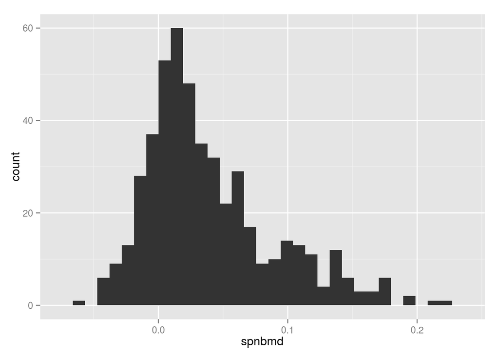

```r
library(ggplot2)
URL <- 'http://statweb.stanford.edu/~tibs/ElemStatLearn/datasets/bone.data'
bone <- read.table(URL, header = TRUE)
qplot(spnbmd, data=bone)
```

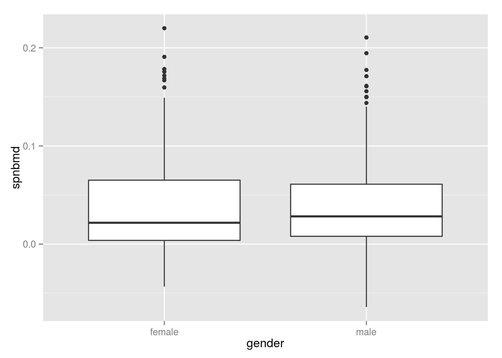

```r
qplot(x=gender, y=spnbmd, data=bone, geom='boxplot')
```

```
## stat_bin: binwidth defaulted to range/30. Use 'binwidth = x' to adjust this.
## stat_bin: binwidth defaulted to range/30. Use 'binwidth = x' to adjust this.
```

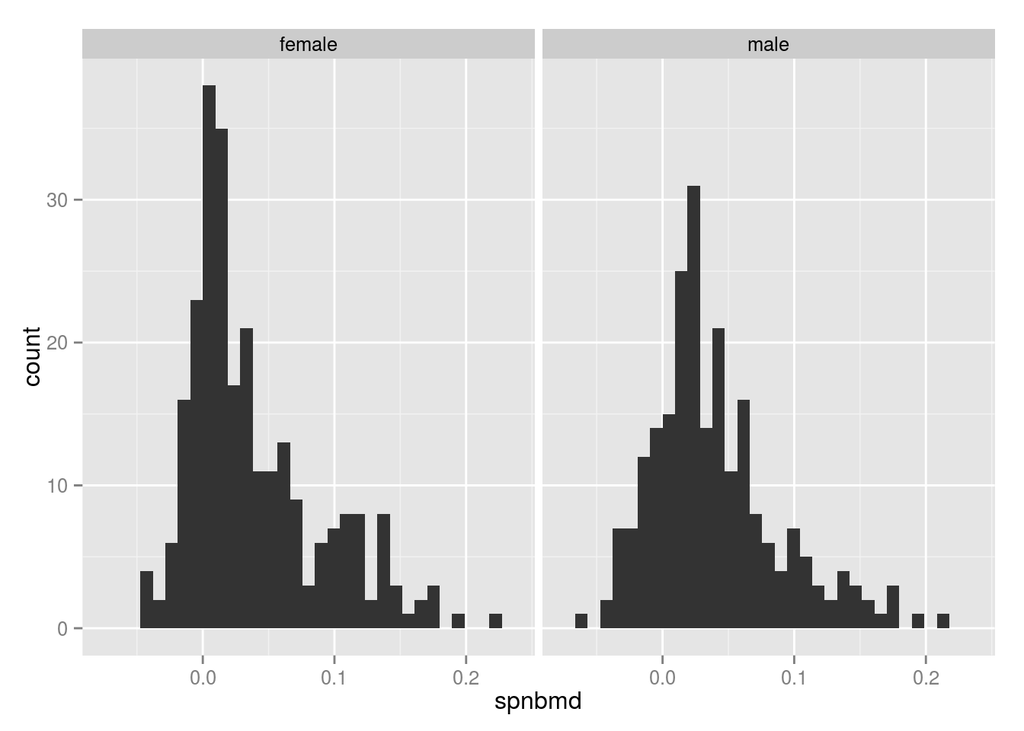

```r
qplot(spnbmd, data=bone, geom='histogram')+ facet_wrap(~gender)
```

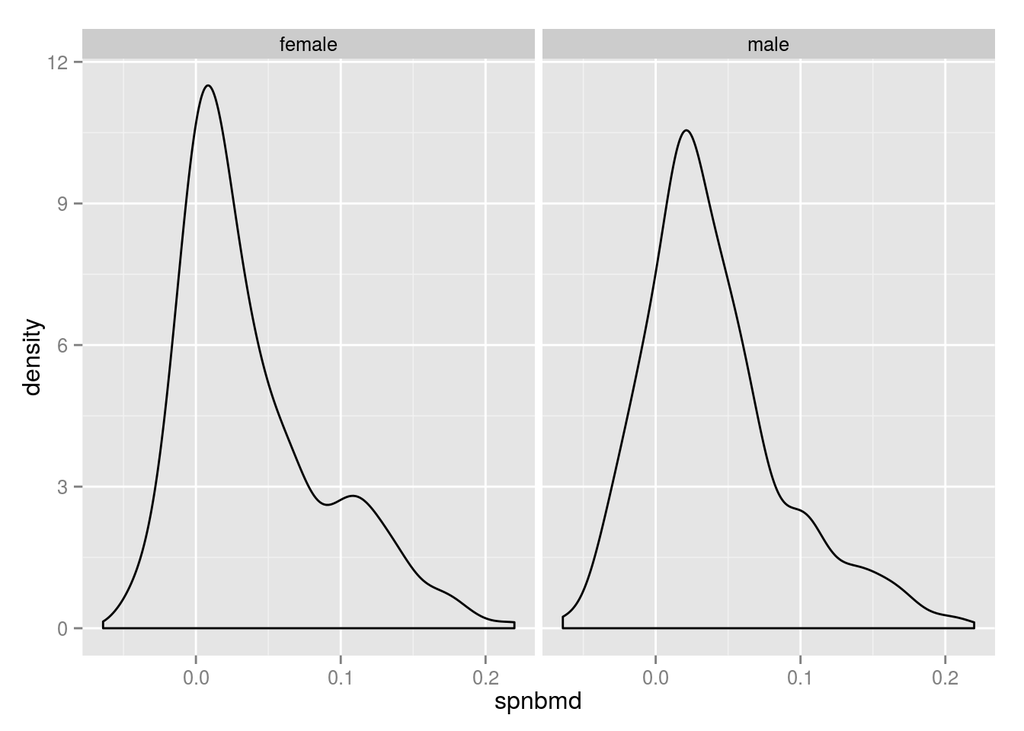

```r
qplot(spnbmd, data=bone, geom='density')+ facet_wrap(~gender)
```

```
## stat_bin: binwidth defaulted to range/30. Use 'binwidth = x' to adjust this.
## stat_bin: binwidth defaulted to range/30. Use 'binwidth = x' to adjust this.
```

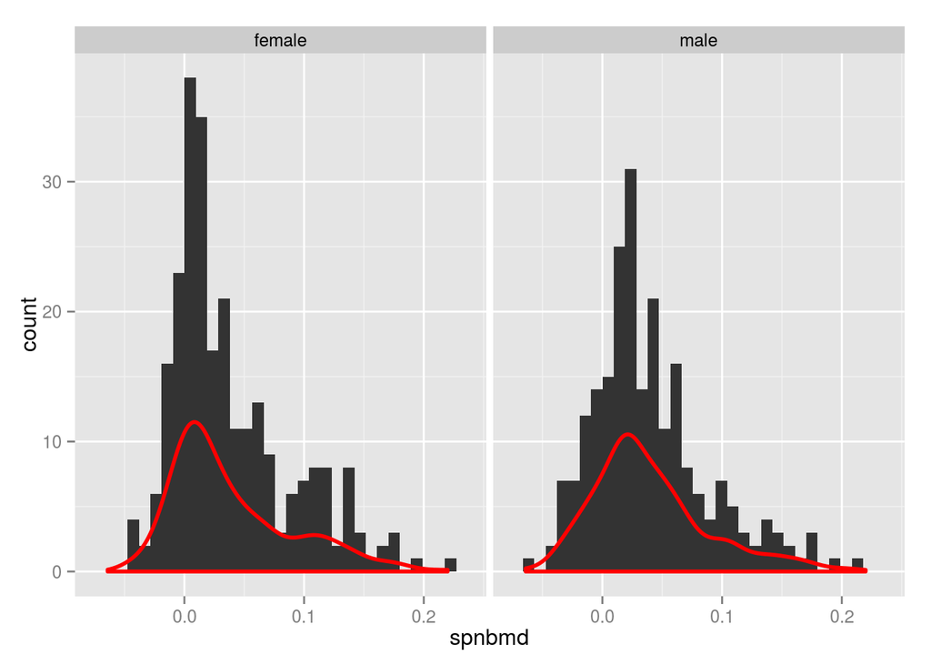

```r
qplot(spnbmd, data=bone)+ geom_density(col='red', size=1)+ facet_wrap(~gender)
```

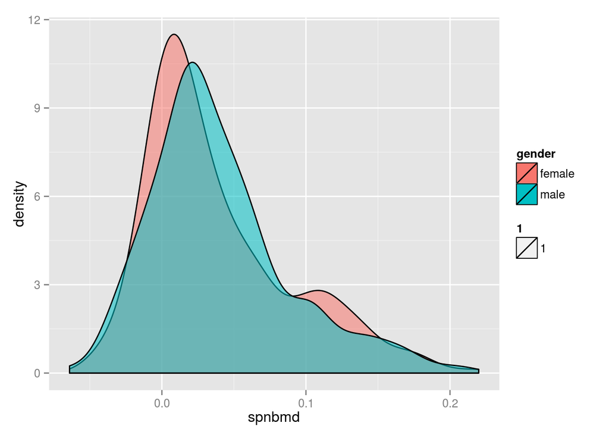

```r
qplot(spnbmd, data=bone, fill=gender, geom='density', alpha=1)
```

Notice data is usually in *Long* format

Diamonds example (Taken from Wickham’s web site: http://had.co.nz/stat405/)

```r
?diamonds
dim(diamonds)
```

```
## [1] 53940    10
```

```r
head(diamonds)
```

```
##   carat       cut color clarity depth table price    x    y    z
## 1  0.23     Ideal     E     SI2  61.5    55   326 3.95 3.98 2.43
## 2  0.21   Premium     E     SI1  59.8    61   326 3.89 3.84 2.31
## 3  0.23      Good     E     VS1  56.9    65   327 4.05 4.07 2.31
## 4  0.29   Premium     I     VS2  62.4    58   334 4.20 4.23 2.63
## 5  0.31      Good     J     SI2  63.3    58   335 4.34 4.35 2.75
## 6  0.24 Very Good     J    VVS2  62.8    57   336 3.94 3.96 2.48
```

```
## stat_bin: binwidth defaulted to range/30. Use 'binwidth = x' to adjust this.
```

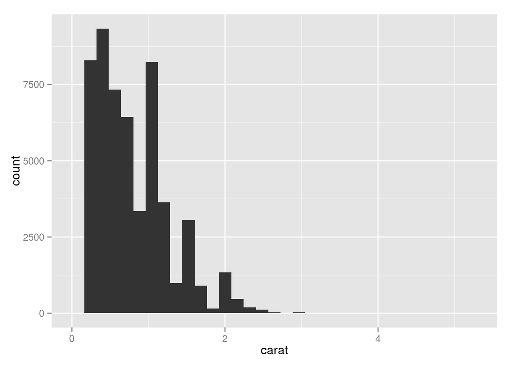

```r
qplot(carat, data = diamonds)
```

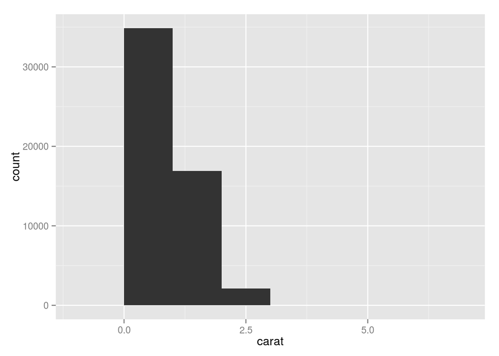

```r
qplot(carat, data = diamonds, binwidth = 1)
```

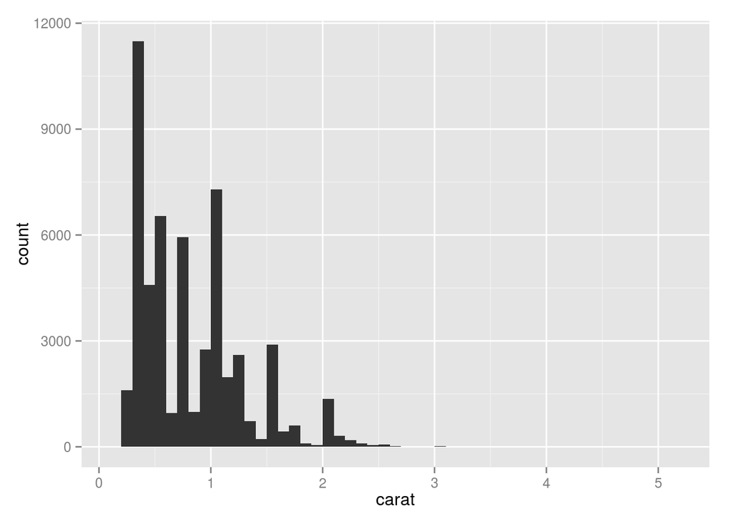

```r
qplot(carat, data = diamonds, binwidth = 0.1)
```

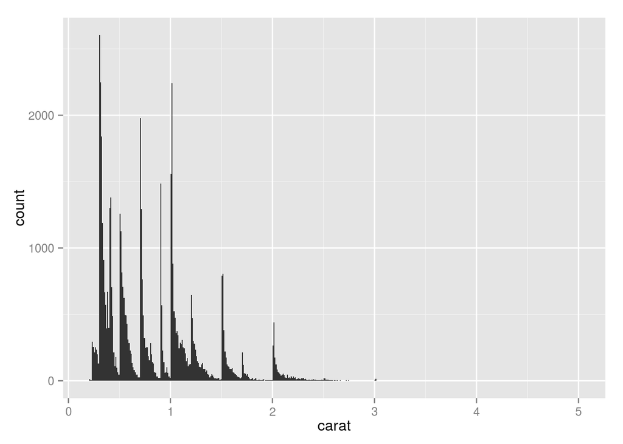

```r
qplot(carat, data = diamonds, binwidth = 0.01)
```

```r
resolution(diamonds$carat)
```

```
## [1] 0.01
```

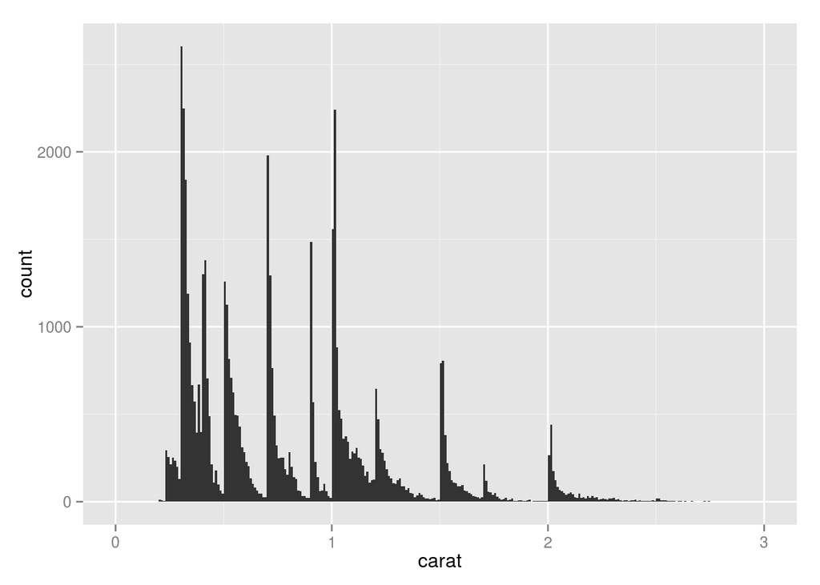

```r
last_plot() + xlim(0, 3)
```

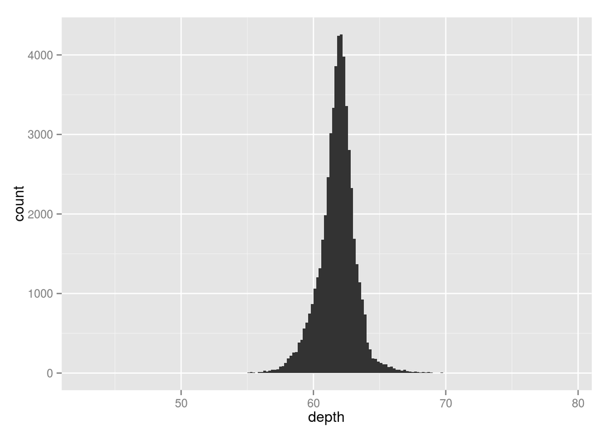

```r
qplot(depth, data = diamonds, binwidth = 0.2)
```

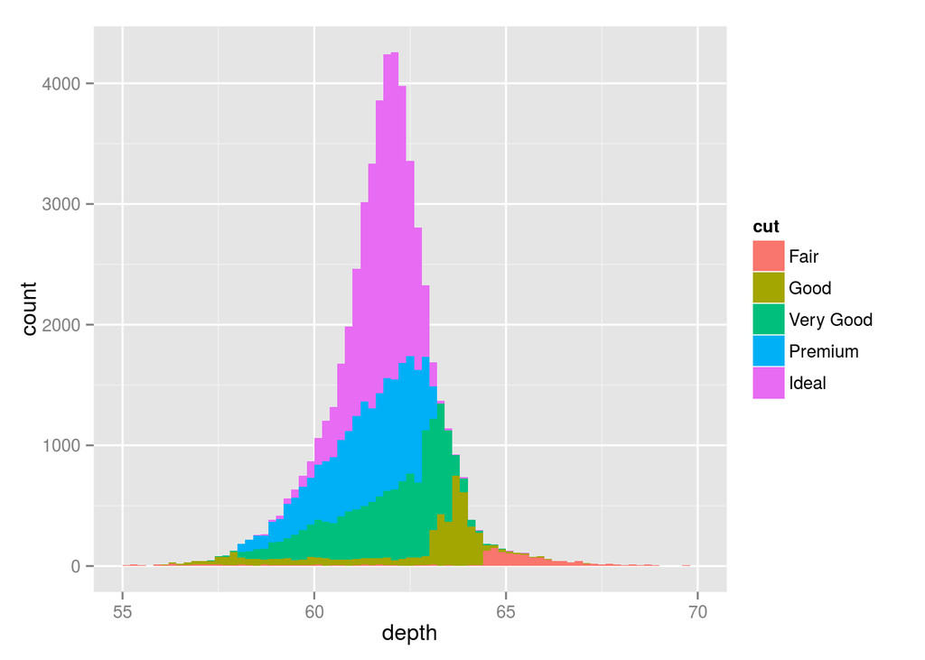

```r
qplot(depth, data = diamonds, binwidth = 0.2,fill = cut) + xlim(55, 70)
```

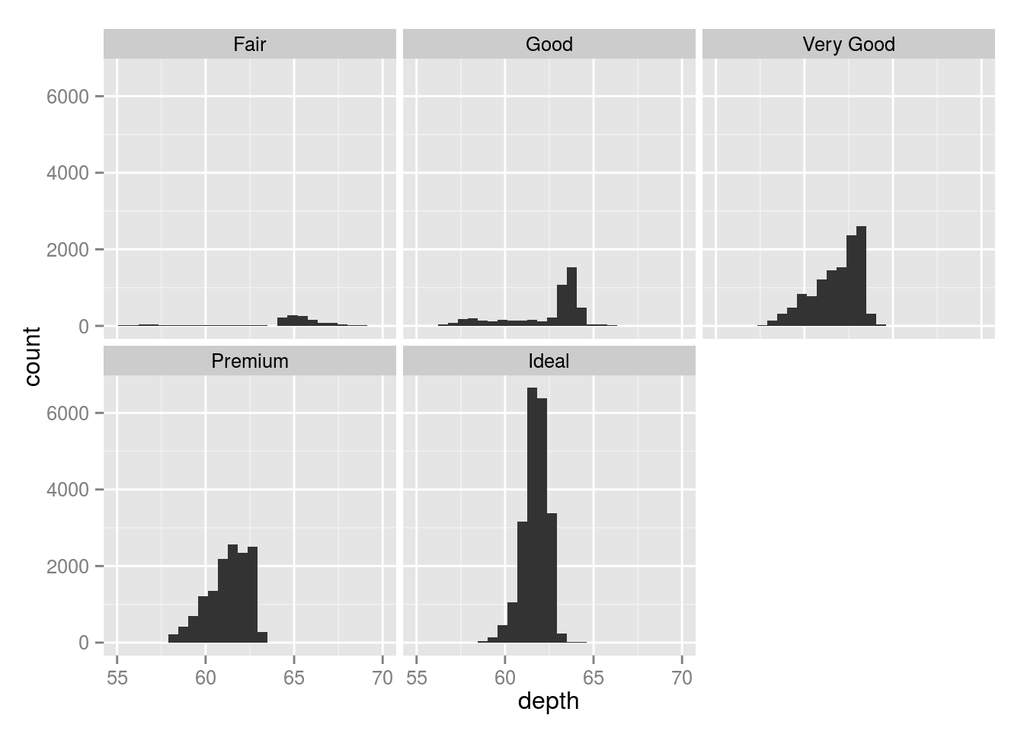

```r
qplot(depth, data = diamonds, binwidth = 0.562) +xlim(55, 70) + facet_wrap(~ cut)
```

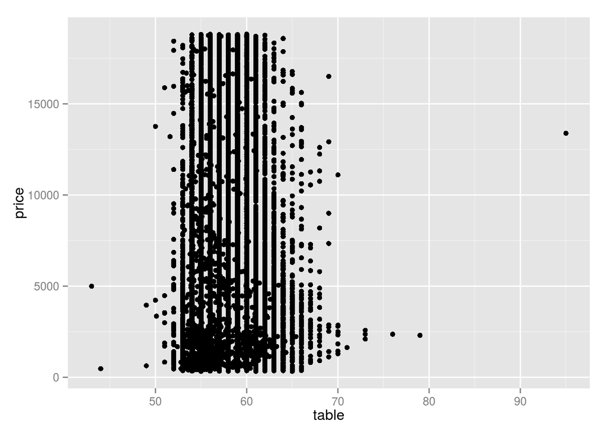

```r
qplot(table, price, data = diamonds)
```

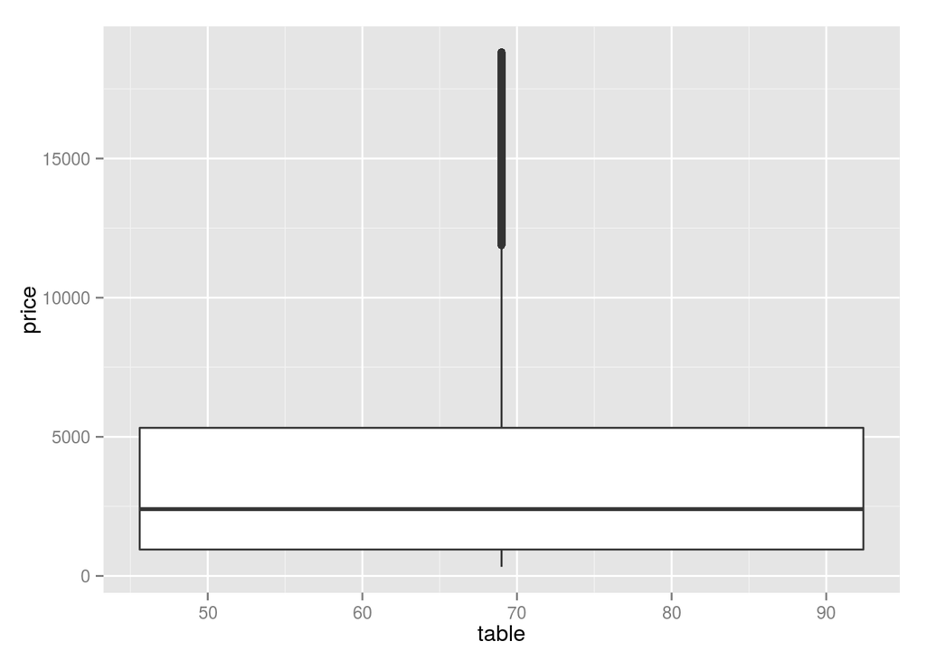

```r
qplot(table, price, data = diamonds, geom = "boxplot")
```

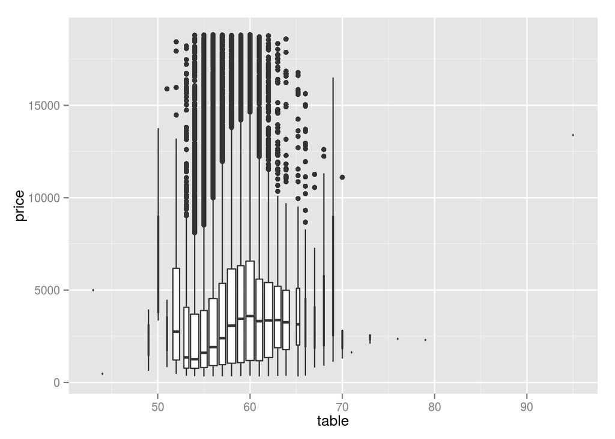

```r
qplot(table, price, data = diamonds, geom="boxplot",group = round(table))
```

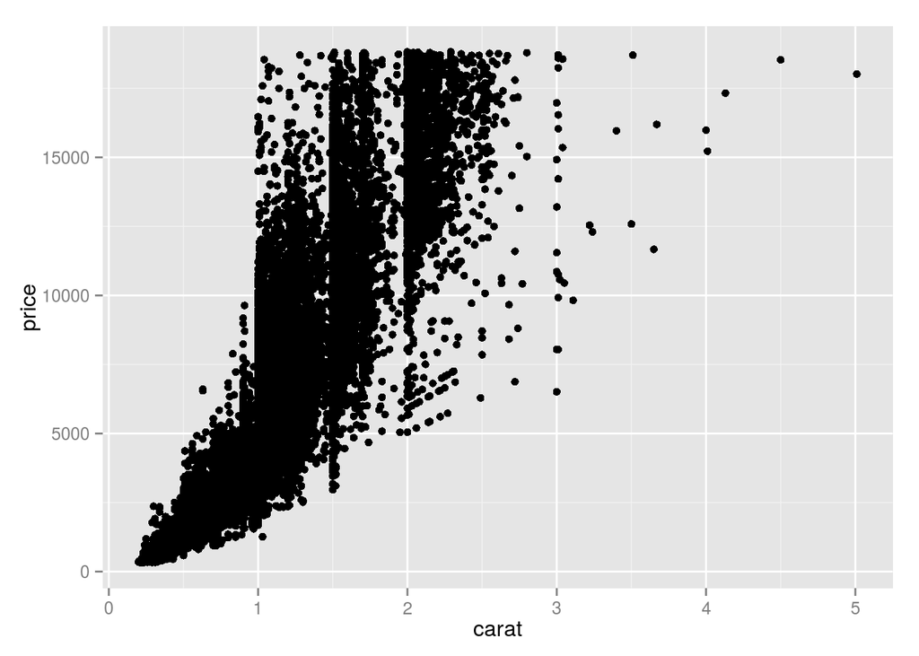

```r
qplot(carat, price, data = diamonds)
```

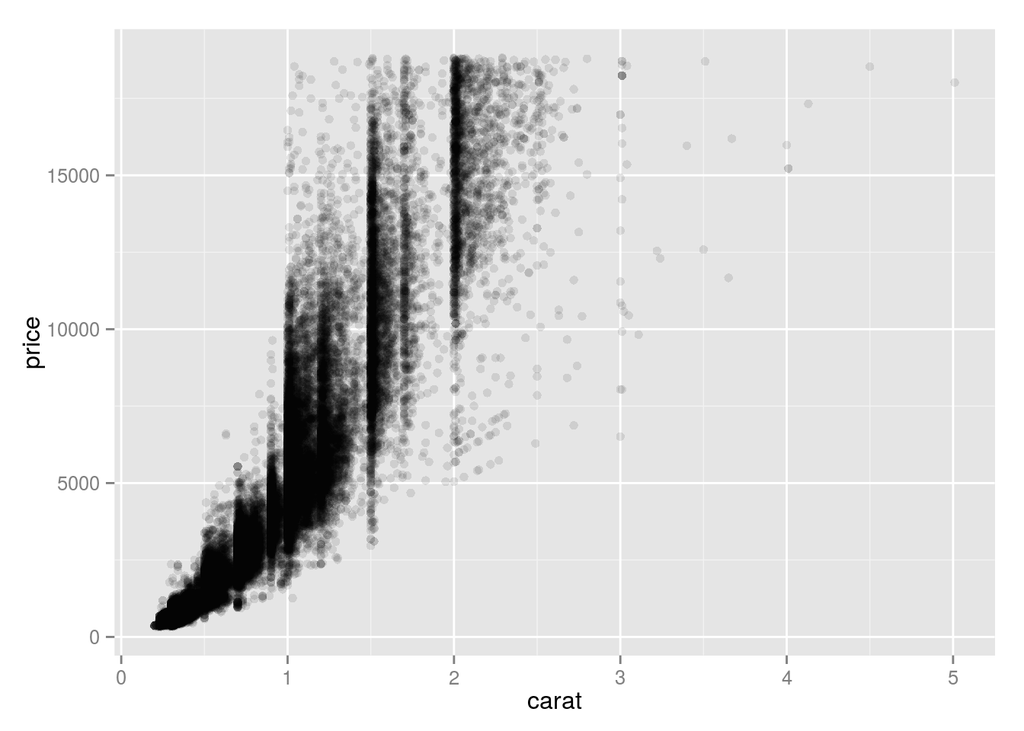

```r
qplot(carat, price, data = diamonds, alpha = I(1/10))
```

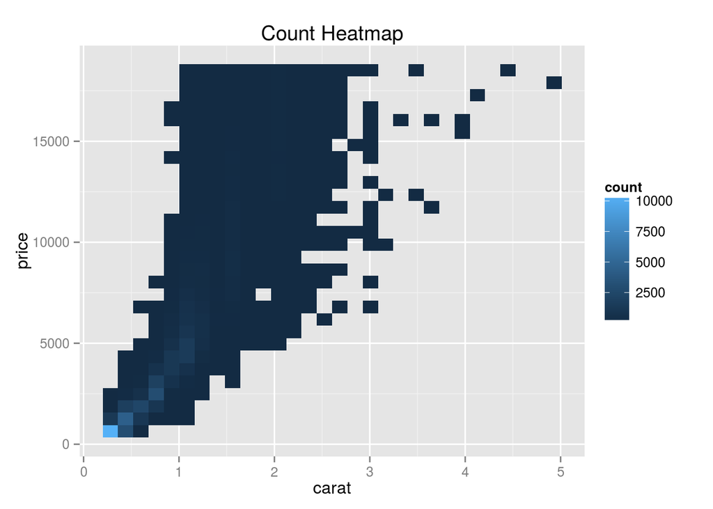

```r
qplot(carat, price, data = diamonds, geom = "bin2d", main='Count Heatmap')
```

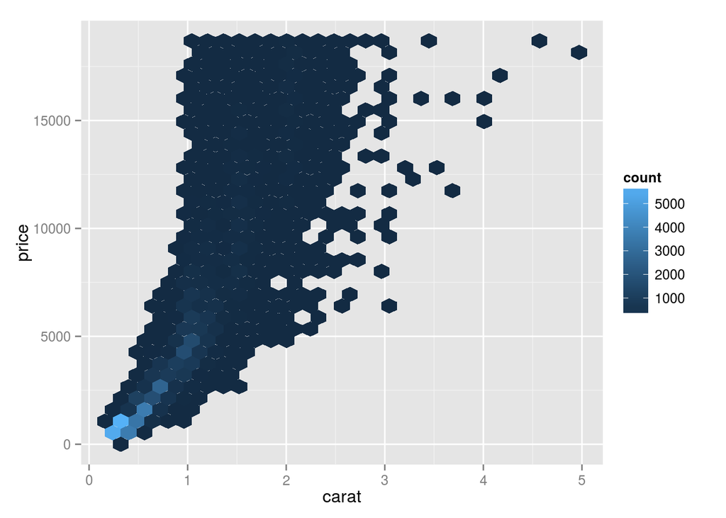

```r
qplot(carat, price, data = diamonds, geom = "hex")
```

```
## geom_smooth: method="auto" and size of largest group is >=1000, so using gam with formula: y ~ s(x, bs = "cs"). Use 'method = x' to change the smoothing method.
```

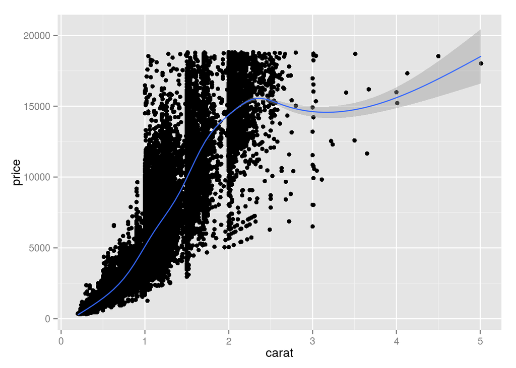

```r
qplot(carat, price, data = diamonds) + geom_smooth()
```

For more information on ggplot2 see http://had.co.nz/ggplot2

#### ————-Interactive Plotting ————

# install.packages(“iplots”)

library(iplots)

data(iris) attach(iris) iplot(Sepal.Width,Petal.Width) iplot(Sepal.Width/Sepal.Length, Species) ihist(iris$Sepal.Width) ibar(Species)

## Note: For more powerfull interactive plotting try:

# 1. Mondrian (open source)

# 2. JMP (expensive)

# 3. Ggobi and Rggobi (open source)

#### —————- Robustness of *location* Summaries————

x<- rnorm(11) last.observations<- seq(1,1000,by=100) means<- numeric(length=0) medians<- numeric(length=0) mean05<- numeric(length=0) for (y in last.observations){ all.data<- c(x,y) means<- c(means, mean(all.data)) medians<- c(medians, median(all.data)) mean05<- c(mean05, mean(all.data, trim=0.1))  
}

expanded.data<- expand.grid(x=x, y=last.observations) with(expanded.data, boxplot(x~y, xlab=‘Last Observation’)) lines(means~last.observations, lty=2, lwd=3, col=‘red’) lines(medians~last.observations, lty=3, lwd=3, col=‘brown’) lines(mean05~last.observations, lty=4, lwd=3, col=‘blue’)

#### —————-Spread & Symmetry Summaries—————

x1<-rnorm(1000, 100, 50) x2<-rexp(1000, 1/100) x3<-rgamma(1000, 3, 1/30) x4<-rf(1000, 100, 1)/100

plot(density(x1));#abline(v=100, lty=2);abline(v=0, lty=2) plot(density(x2));#abline(v=100, lty=2);abline(v=0, lty=2) plot(density(x3));#abline(v=100, lty=2);abline(v=0, lty=2) plot(density(x4));#abline(v=100, lty=2);abline(v=0, lty=2)

boxplot(x1, x2, x3, x4, ylim=c(-100, 400))

#### ————– Measures of spread———————–

cat(‘SD=’, sqrt(var(x1)), ‘MAD=’, mad(x1), ‘IQR=’, IQR(x1), ‘’) cat(‘SD=’, sqrt(var(x2)), ‘MAD=’, mad(x2), ‘IQR=’, IQR(x2), ‘’) cat(‘SD=’, sqrt(var(x3)), ‘MAD=’, mad(x3), ‘IQR=’, IQR(x3), ‘’) cat(‘SD=’, sqrt(var(x4)), ‘MAD=’, mad(x4), ‘IQR=’, IQR(x4), ‘’)

#### (~<sub>~</sub>)——————– Symmetry Function ——————

my.symetry<-function(x, i) { x<-sort(x) n<-length(x) mean(c(x[i], x[n-i+1])) - median(x) #A functions returns the last evaluation unless asked otherwise } my.symetry(x1, 2)

my.spread<-function(x, i) { x<-sort(x) n<-length(x) -0.5*(c(x[i]-x[n-i+1])) }

n<-floor(length(x1)/2) y1<-rep(0, n)  
y1.1<-rep(0, n) for (i in 1:n ) { y1[i]<-my.symetry(x1, i) } for (i in 1:n ) { y1.1[i]<-my.spread(x1, i) }

par(mfrow=c(3, 1));plot(y1);abline(h=0) plot(y1 / y1.1);abline(h=0);abline(v=n/2) plot(density(x1));par(mfrow=c(1, 1))

n<-floor(length(x4)/2);y4<-rep(0, n) for (i in 1:n ) { y4[i]<-my.symetry(x4, i) } par(mfrow=c(2, 1));plot(y4);plot(density(x4));par(mfrow=c(1, 1))

#### —————- Yule Skewness measure——————

boxplot(x1, x2, x3) boxplot(x1, x2, x3, x4)

yule<-function(x) { (mean(c(quantile(x, 0.25), quantile(x, 0.75))-median(x))) / ( IQR(x)/2 ) }

yule(x1);yule(x2);yule(x3);yule(x4)

#### —————–Pearson Skewness Measure—————-

pearson(x1) pearson(x2) pearson(x3) pearson(x4)

#### ————- Sensitivity Function——————–

(new.obs<- -1000:1000) mean.sensitivity<- rep(0,length(new.obs)) median.sensitivity<- rep(0,length(new.obs)) alpha.t.sensitivity<- rep(0,length(new.obs)) sd.sensitivity<- rep(0,length(new.obs)) mad.sensitivity<- rep(0,length(new.obs)) iqr.sensitivity<- rep(0,length(new.obs)) pearson.sensitivity<- rep(0,length(new.obs)) yule.sensitivity<- rep(0,length(new.obs))

for (i in seq_along(new.obs)){ temp.data<- c(x1,new.obs[i])

```
mean.sensitivity[i]<- mean(temp.data)
median.sensitivity[i]<- median(temp.data)
alpha.t.sensitivity[i]<- mean(temp.data, trim=0.1)
pearson.sensitivity[i]<- pearson(temp.data)
yule.sensitivity[i]<- yule(temp.data)
sd.sensitivity[i]<- sd(temp.data)
mad.sensitivity[i]<- mad(temp.data)
iqr.sensitivity[i]<- IQR(temp.data)
```

}

plot(mean.sensitivity~new.obs, type=‘l’) lines(median.sensitivity~new.obs, lty=2) lines(alpha.t.sensitivity~new.obs, lty=3) legend(locator(1), legend=c(‘Mean’,‘Meadian’,‘Alpha Trimmed’), lty=c(1,2,3)) abline(v=median(x1),lty=5) abline(v=quantile(x1,0.1),lty=6) abline(v=quantile(x1,0.9),lty=6)

#### —————-Univariate transformations————————-

(periods<-c(rnorm(500, 15),rnorm(100, 10))) (cells<-10*2^periods)

hist(cells); rug(cells) hist(log(cells)); rug(log(cells))

#### (~<sub>~</sub>)————The Power Family Transforms—————–

curve(log, 0,10, xlim=c(0,10), ylim=c(0,15), col=‘red’) # The Log transformations abline(v=0);abline(h=0);

ps<- c(-2,-3/2,-1,-2/3,-1/2,1/2,2/3,1,3/2,2) # Selected powers for (p in ps){ p.trans<- function(x) (x^p - 1) / p curve(p.trans, 0, 10, add=T) }

hist(x3) transformed.x3<- matrix(0, ncol=length(ps), nrow=length(x3)) for (i in seq_along(ps)){ p<- ps[i] transformed.x3[,i]<- (x3^p - 1) / p }

apply(transformed.x3, 2, pearson) apply(transformed.x3, 2, yule)

colnames(transformed.x3)<- paste(round(ps,2)) boxplot(transformed.x3) boxplot(transformed.x3,ylim=c(0,100))

————Normal Distribution———————

# The Standard normal distribution (a.k.a. Gaussian)

mu<-0;sd<-1;curve(dnorm(x, mean=mu, sd=sd), -5, 5, ylim=c(0, 1), col=‘red’);abline(v=mu)  
#Non standard normal distribution mu<-0;sd<-0.5;curve(dnorm(x, mean=mu, sd=sd), add=T);abline(v=mu) mu<-1;sd<-2;curve(dnorm(x, mean=mu, sd=sd), add=T) mu<–2;sd<-.2;curve(dnorm(x, mean=mu, sd=sd), add=T)

curve(pnorm(x, 0, 1), -4, 4, main=‘Commulative Standard Normal’);abline(v=0);abline(0.5, 0, lty=2) curve(pnorm(x, 0, 1), -10, 10, main=‘Commulative Standard Normal’);abline(v=0);abline(0.5, 0, lty=2) curve(pnorm(x, 0, 3), -10, 10, add=T, col=‘red’) curve(pnorm(x, 0, 5), -10, 10, add=T, col=‘blue’)

curve(pnorm(x, 0, 1), -10, 10, main=‘Commulative Standard Normal’);abline(v=0);abline(0.5, 0, lty=2) curve(pnorm(x, -1, 1), -10, 10, add=T, col=‘red’) curve(pnorm(x, 1, 1), -10, 10, add=T, col=‘blue’) legend(x=-7, y=0.8, legend=c(expression(mu==0), expression(mu==1), expression(mu==-1)), lty=1, col=c(‘black’, ‘blue’, ‘red’))

pnorm(0, mean=0, sd=1) ## Commulative density function (CDF) pnorm(1.5, mean=0, sd=1) pnorm(510, mean=500, sd=11)

qnorm(0.2, mean=0, sd=1) ## Inverse commulative density function (ICDF) a.k.a. Quantile fucntion. qnorm(0.5, mean=0, sd=1) qnorm(0.975, mean=10, sd=7)

dnorm(0, mean=0, sd=1) ## Probability density function

# The normal approximation of the binomial distribution

n<-100;p<-0.5 curve(dbinom(x, n, p), 0, n, type=‘h’, ylim=c(0, 1)) curve(pbinom(x, n, p), 0, n, type=‘S’, ylim=c(0, 1)) # The Commulative binomial probaility function curve(pnorm(x, mean=n*p, sd=sqrt(n*p*(1-p))), add=T, col=‘red’)

n<-1000;p<-0.5 curve(pbinom(x, n, p), 0, n, type=‘s’, ylim=c(0, 1)) # The Commulative binomial probaility function curve(pnorm(x, mean=n*p, sd=sqrt(n*p*(1-p))), add=T, col=‘red’)

n<-10;p<-0.5 curve(pbinom(x, n, p), 0, n, type=‘S’, ylim=c(0, 1)) # The Commulative binomial probaility function curve(pnorm(x, mean=n*p, sd=sqrt(n*p*(1-p))), add=T, col=‘red’)

n<-10;p<-0.05 curve(pbinom(x, n, p), 0, n, type=‘S’, ylim=c(0, 1)) # The Commulative binomial probaility function curve(pnorm(x, mean=n*p, sd=sqrt(n*p*(1-p))), add=T, col=‘red’) curve(dbinom(x, n, p), 0, n, type=‘h’, ylim=c(0, 1))

# Demonstrating the C.L.T. (Central limit theorem) using geometric distribution

rgeom(100, 0.3) hist(rgeom(1000, 0.3)) generating<-matrix(0, ncol=100, nrow=1000)

for (i in 1:1000) generating[i, ]<-rgeom(100, 0.3) generating

sums<-apply(generating, 1, sum);sums length(sums)

par(mfrow=c(1, 2));hist(rgeom(1000, 0.3), main=‘Original Geometric Distribution’);hist(sums, main=‘Distribution of sum’);par(mfrow=c(1, 1))

# Generate data:

some.data<- rnorm(1000) hist(some.data, probability=TRUE) lines(density(some.data)) rug(some.data)

(some.mean<- mean(some.data)) (some.sd<- sd(some.data)) abline(v=some.mean+c(-1,1)*some.sd, col=‘red’, lwd=3)

table(some.data < some.mean-some.sd) prop.table(table(some.data < some.mean-some.sd)) prop.table(table(some.data > some.mean+some.sd))

#### The QQ plot

mystery.2<-function(y) { n<-length(y) y<-sort(y) i<-1:n q<-(i-0.5)/n x<-qnorm(q, mean(y), sqrt(var(y))) plot(y~x, xlab=‘Theoretical Quantiles’, ylab=‘Empirical Quantiles’) }

normals.1<-rnorm(100, 0, 1);hist(normals.1) mystery.2(normals.1);abline(0, 1)

normals.2<-rnorm(100, 0, 10);hist(normals.2) mystery.2(normals.2);abline(0, 1)

## No need to write the function every time…

qqnorm(normals.1)  
qqnorm(normals.2)

## How would non-normal observations look?

non.normals.1<-runif(100);hist(non.normals.1) mystery.2(non.normals.1);abline(0, 1)

non.normals.2<-rexp(100, 1);hist(non.normals.2) mystery.2(non.normals.2);abline(0, 1)

non.normals.3<-rgeom(100, 0.5);hist(non.normals.3) mystery.2(non.normals.3);abline(0, 1)

## Adapting for a non-normal distribution:

qq.uniform<-function(y) { n<-length(y); y<-sort(y); i<-1:n; q<-(i-0.5)/n x<-qunif(q, min=min(y), max=max(y)) #each disribution will require it’s own parameters! plot(y~x, xlab=‘Theoretical Quantiles’, ylab=‘Empirical Quantiles’) } qq.uniform(non.normals.1);abline(0, 1) qq.uniform(non.normals.2);abline(0, 1) qq.uniform(normals.2);abline(0, 1)

#### The normal approximation of the binomial distribution

# Empirical example

n<-10;p<-0.2;binom.data=rbinom(100, n, p);mystery.2(binom.data);abline(0, 1) n<-10;p<-0.5;binom.data=rbinom(100, n, p);mystery.2(binom.data);abline(0, 1) n<-100;p<-0.5;binom.data<-rbinom(100, n, p);mystery.2(binom.data);abline(0, 1) n<-1000;p<-0.5;binom.data<-rbinom(100, n, p);mystery.2(binom.data);abline(0, 1)

# Analytic example

n<-100;p<-0.5 curve(dbinom(x, n, p), 0, n, type=‘h’, ylim=c(0, 1)) curve(pbinom(x, n, p), 0, n, type=‘S’, ylim=c(0, 1)) # The Commulative binomial probaility function curve(pnorm(x, mean=n*p, sd=sqrt(n*p*(1-p))), add=T, col=‘red’)

n<-1000;p<-0.5 curve(pbinom(x, n, p), 0, n, type=‘s’, ylim=c(0, 1)) # The Commulative binomial probaility function curve(pnorm(x, mean=n*p, sd=sqrt(n*p*(1-p))), add=T, col=‘red’)

n<-10;p<-0.5 curve(pbinom(x, n, p), 0, n, type=‘S’, ylim=c(0, 1)) # The Commulative binomial probaility function curve(pnorm(x, mean=n*p, sd=sqrt(n*p*(1-p))), add=T, col=‘red’)

n<-10;p<-0.05 curve(pbinom(x, n, p), 0, n, type=‘S’, ylim=c(0, 1)) # The Commulative binomial probaility function curve(pnorm(x, mean=n*p, sd=sqrt(n*p*(1-p))), add=T, col=‘red’) curve(dbinom(x, n, p), 0, n, type=‘h’, ylim=c(0, 1))

#### ———–*Simultanous* analysis of multiple *continous* data vectors —–

#### —————-Scatter plots—————-

# Sine function

x<-seq(-pi, pi, 0.01) y<-sin(x) plot(y~x)

# Exponent function

x<-seq(-pi, pi, 0.01) y<-exp(x) plot(y~x)

# Sinc function

x<-seq(-10*pi, 10*pi, 0.01) y<-sin(x)/x plot(y~x)

# Fancy function

## Some real life data

ozone<-read.table(‘http://www-stat.stanford.edu/~tibs/ElemStatLearn/datasets/ozone.data’, header=T) names(ozone)

plot(ozone)

#### ———– 3D plotting (windows only) ————-

install.packages(‘rgl’) library(rgl) plot3d(ozone[, 1:3])

#### ——- Plotting a surface —-

x<-seq(0, 1, 0.01) y<-seq(0, 1, 0.01) xy.grid<-expand.grid(x, y) func1<-function(mesh) exp(mesh[, 1]+mesh[, 2]) z<-func1(xy.grid) xyz<-data.frame(xy.grid, z) plot3d(xyz, xlab=‘x’, ylab=‘y’)

# For interacting with plots try the RGGobi package.

#### —————- Fitting a linear function ——————–

# Well behaved data

x<-1:100 a<-2 b<-3.5 sigma<-10 y<-a+b*x+rnorm(100, 0, sigma) plot(y~x)

#### ———- Ordinary Least Squares ———–

ols.line<-function(x, y){ sxy<-sum( (x-mean(x) ) * (y-mean(y) ) )  
sxx<-sum( (x-mean(x)) ^ 2 ) b1<-sxy / sxx a1<-mean(y) - b1 * mean(x) return(list(slope=b1, intercept=a1)) }

ols<-ols.line(x, y) ; ols abline(ols$intercept, ols$slope, lty=2, lwd=3) predictions = ols$intercept + ols$slope * x residuals<- y - predictions plot(residuals) ; abline(h=0)

#### ————— Robust regression—————–

rline <- function(x, y) { ind<- is.na(x) | is.na(y) x<- x[!ind] y<- y[!ind] o <- order(x) #The permutation that will sort x the into ascending order. x <- sort(x) #The sorted x vector y <- y[o] #The sorted y vector n <- length(x) #The length of the dataset n3 <- round(n/3) xb <- median(x[c(1:n3)]) #The median of the x of the lower part yb <- median(y[c(1:n3)]) #The median of the y of the lower part xt <- median(x[c((n - n3 + 1):n)]) #The median of the x of the upper part yt <- median(y[c((n - n3 + 1):n)]) #The median of the y of the upper part b1 <- (yt-yb)/(xt-xb) # Calculating the slope b0 <- mean(yt, yb)-b1*mean(xt, xb) # Calculating the (temporary) intercept pred <- b0 + b1* x  
mr <- median(y - pred) #The adjustment to the median of the initial residuals b0 <- b0 + mr #The “adjusted” intercept pred <- b0 + b1 * x #The final predictions resid <- y - pred #The final errors return(list(intercept=b0, slope=b1, pred=pred, resid=resid, x=x, xb=xb, yb=yb, xt=xt, yt=yt)) }

robust <- rline(x, y) robust$intercept ; robust$slope plot(y~x) abline(robust$intercept, robust$slope, col=‘red’, lwd=3, lty=2)

## Ill Behaved data

y<-a+b*x+rbinom(100, 1, 0.1)*(rbinom(100, 1, 0.5)-0.5)*10000 plot(y~x, ylim=c(-1, 1)*5000) ; abline(a, b, col=‘blue’, lwd=3, lty=5)

plot(y~x, ylim=c(-1, 1)*500) ; abline(a, b, col=‘blue’, lwd=3, lty=5) ols.ill<-ols.line(x, y);ols.ill abline(ols.ill$intercept, ols.ill$slope, col=‘brown’) robust.ill<-rline(x, y) abline(robust.ill$intercept, robust.ill$slope, col=‘red’) legend(x=60,y=-200, lty=1, legend=c(‘Real’, ‘OLS line’, ‘Robust Line’), col=c(‘blue’, ‘brown’, ‘red’), lwd=c(3, 1, 1))

#### ——- How are the intercept and slope related? (Simulation Study)—-

x<-1:100 a<-2 b<-3.5 sigma<-10 iterations<-100 retries<-matrix(0, 2*iterations, ncol=2) for (i in 1:iterations){ y<-a+b*x+rnorm(100, 0, sigma) temp.robust<-rline(x, y)  
retries[i, 1]<-temp.robust$slope-b retries[i, 2]<-temp.robust$intercept-a }

ind<- as.numeric((retries[, 1]>0) & (retries[, 2]>0))+1 plot(retries, xlab=‘Deviation from real slope’, ylab=‘Deviation from real intercept’, pch=ind)  
abline(v=0);abline(h=0)

#### ——— What is a high correlation?—————

samples<- 100 x <- 1:samples a <- 2 b <- 3.5 sigma <- 500 y <- a+b*x+rnorm(samples, 0, sigma) (initial.correlation<- cor(y,x))

# Permute the data and compute the correlation:

iterations<-1000 correlations<- rep(NA, iterations) for (i in 1:iterations){ ind<- sample(length(y)) correlations[i] <- cor(y[ind], x) } hist(correlations, xlim=c(-1,1)) rug(correlations) abline(v=initial.correlation)

#### Extrapolation

x<-runif(1000)*5 y<-exp(x)+rnorm(1000) plot(y~x, main=‘Whole relation’)

rect(xleft=0, ybottom=-5, xright=2, ytop=10)

plot(y~x, main=‘Local relation’, cex=0.5, xlim=c(0, 2), ylim=c(-5, 10));abline(v=2, lty=3)

ind<-x<=2;ind ols.interpolating<-ols.line(x[ind], y[ind]);ols.interpolating abline(ols.interpolating$intercept , ols.interpolating$slope, col=‘red’) text(x=0.5, y=6, labels=‘Interpolates Nicely’, cex=2)

plot(y~x, main=‘Whole relation’) abline(ols.interpolating$intercept , ols.interpolating$slope, col=‘red’) abline(v=2, lty=3) text(x=2, y=121, labels=‘Extrapolates Terribly!’, cex=2)

# Non-linearity might be fixed with a transformation:

# Which of the following looks better (more linear)?

Intuition: Pearson’s correlation is the *OLS* slope if dealing with *standardized* variables.

x<-1:100;cat(‘Old X average=’, mean(x), ‘. Old X Variance=’, var(x), ‘’) a<-2 ; b<-3.5 ; sigma<-10 y<-a+b*x+rnorm(100, 0, sigma);cat(‘Old Y average=’, mean(y), ‘. Old Y Variance=’, var(y), ‘’) plot(y~x)

x.stan<-(x-mean(x))/sqrt(var(x));cat(‘New X average=’, mean(x.stan), ‘. New X variance=’, var(x.stan), ‘’) y.stan<-(y-mean(y))/sqrt(var(y));cat(‘New Y average=’, round(mean(y.stan), 2), ‘. New Y variance=’, var(y.stan), ‘’) plot(y~x, cex=0.5);points(y.stan~x.stan, col=‘red’)

ols.line(x.stan, y.stan) # Calculating the slope in Z-score scale cor(x.stan, y.stan) # Calculating the correlation coef of the Z-scores #MatLab: corrcoef cor(x, y) # The cor coef in the original scale is the same as the slope in Z-score scale!

## Multivariate linear regression

library(rgl)

xy.grid <- data.frame(x1=runif(10000), x2=runif(10000))

func1<-function(mesh, a0, a1, a2, sigma) { n<-nrow(mesh) a0 + a1 * mesh[, 1] + a2 * mesh[, 2] + rnorm(n, 0, sigma) }

# More noise hides the stucture in the data:

z<-func1(xy.grid, a0=5, a1=1, a2=3, .0);z;xyz=data.frame(xy.grid, z);plot3d(xyz, xlab=‘x1’, ylab=‘x2’) z<-func1(xy.grid, a0=5, a1=1, a2=3, .4);xyz=data.frame(xy.grid, z);plot3d(xyz, xlab=‘x1’, ylab=‘x2’) z<-func1(xy.grid, a0=5, a1=1, a2=3, 11);xyz=data.frame(xy.grid, z);plot3d(xyz, xlab=‘x1’, ylab=‘x2’)

z<-func1(xy.grid, a0=5, a1=1, a2=3, .4);xyz=data.frame(xy.grid, z);plot3d(xyz, xlab=‘x1’, ylab=‘x2’) lm(z~., xyz) #Solves the system “prediction=(X’X)^-1 X’y”

###### Linearizing Transformations and Examining Residuals

## See also http://www.gapminder.org/

## Log example #1:

x<-runif(1000)*5 y<-exp(x)+rnorm(1000) plot(y~x, main=‘Whole relation’) rect(xleft=0, ybottom=-5, xright=2, ytop=10) plot(y~x, main=‘Local relation’, cex=0.5, xlim=c(0, 2), ylim=c(-5, 10));abline(v=2, lty=3) ind<-x<=2;ind ols.interpolating<-ols.line(x[ind], y[ind]);ols.interpolating abline(ols.interpolating$intercept , ols.interpolating$slope, col=‘red’) plot(y~x, main=‘Whole relation’) abline(ols.interpolating$intercept , ols.interpolating$slope, col=‘red’) abline(v=2, lty=3)

yResiduals<- y - (ols.interpolating$intercept+ols.interpolating$slope * x) par(mfrow=c(1,1)) plot(y~x, main=‘Local relation; scatter’, cex=0.5, xlim=c(0, 2), ylim=c(-5, 10));abline(v=2, lty=3); abline(ols.interpolating$intercept , ols.interpolating$slope, col=‘red’) plot(yResiduals ~x, main=‘Local relation; residuals’, cex=0.5, xlim=c(0, 2), ylim=c(-5, 10));abline(0,0) # Note: Non linearity is easier to spot when inspecting residuals!

# Now inspect normality of residuals:

qqnorm(yResiduals); qqline(yResiduals) qqnorm(yResiduals2); qqline(yResiduals2) par(mfrow=c(1,1))

# Has R^2 improved?

## Distribution of y|x:

# Judging by the QQplot: Y|x~N( a+b*exp(x), sigma_e^2) # sigma_e^2 = (1-R^2)* sigma_y^2

# What is your guess of the next value of y?

# What is your guess of the range of 68% of values of y?

plot(y~x, cex=0.2, xlim=c(0,3), ylim=c(0,10)) points(predicted.y~x, col=‘red’, cex=0.2) R2<- compute.R2(exp(x),y) sigma.epsilon<- sqrt( (1-R2)* var(y)) segments(x, predicted.y-sigma.epsilon, x, predicted.y+sigma.epsilon, col=‘lightgrey’, cex=0.2)

#### Log Linear Model

x<- runif(100) a<- 2 b<- 3.5 y<- exp(a+b*x+rnorm(100,sd=0.2)) plot(y~x)

line.1<- ols.line(y=y,x=exp(x)) preds.1<- line.1$intercept + line.1$slope * exp(x) resids.1<- y-preds.1 plot(y~x);points(preds.1 ~ x, col=‘red’) plot(resids.1~x);abline(0,0)

line.2<- ols.line(y=log(y),x=x) preds.2<- exp(line.2$intercept + line.2$slope * x) plot(y~x);points(preds.2 ~ x, col=‘red’) resids.2<- y - preds.2 plot(resids.2~x);abline(0,0) resids.2.2<- log(y) - log(preds.2) plot(resids.2.2~x);abline(0,0)

## Q: What is this good for?!?

## A: Prediction intervals! (amongst others)

# In linear scale:

R2<- compute.R2(x=x,y=log(y)) sigma.epsilon<- sqrt( (1-R2)* var(log(y))) plot(log(y)~x);points(log(preds.2) ~ x, col=‘red’) segments(x, log(preds.2)-sigma.epsilon, x, log(preds.2)+sigma.epsilon, col=‘darkgreen’, cex=0.2) # In exp() scale: plot(y~x); points(preds.2 ~ x, col=‘red’) segments(x, exp(log(preds.2)-sigma.epsilon), x, exp(log(preds.2)+sigma.epsilon), col=‘darkgreen’, cex=0.2)

#### Log-Log Model

x<- runif(100) a<- 2 b<- 3.5 y<- exp(a + b * log(x)+rnorm(100, sd=1)) plot(y~x)

ols.line.1<- ols.line(x=x, y=y) predict.1<- ols.line.1$intercept + ols.line.1$slope * x plot(y~x); points(predict.1~x, col=‘red’)

ols.line.2<- ols.line(x=exp(x), y=y) predict.2<- ols.line.2$intercept + ols.line.2$slope * exp(x) plot(y~x); points(predict.2~x, col=‘red’)

ols.line.3<- ols.line(x=x, y=log(y)) predict.3<- exp(ols.line.3$intercept + ols.line.3$slope * x) plot(y~x); points(predict.3~x, col=‘red’) plot(log(y)~x);points(log(predict.3) ~ x, col=‘red’)

ols.line.4<- ols.line(x=log(x), y=log(y)) predict.4<- exp(ols.line.4$intercept + ols.line.4$slope * log(x)) plot(y~x); points(predict.4~x, col=‘red’) plot(log(y)~x);points(log(predict.4) ~ x, col=‘red’) plot(log(y)~log(x))

(R2<- compute.R2(x=log(x),y=log(y))) sigma.epsilon<- sqrt( (1-R2)* var(log(y))) plot(y~x); points(predict.4 ~ x, col=‘red’) segments(x, exp(log(predict.4)-sigma.epsilon), x, exp(log(predict.4)+sigma.epsilon), col=‘darkgreen’, cex=0.2)

# Interpreting a log-log model:

# b is the *percent* change in y, for a percent change in x!

# Why?

e.y<- expression(exp(a)*x**b) D(e.y,‘x’) # So dy/y = b d/x Hurray!

#### Varying Variance (heteroskedasticity)

x<- runif(100, max=2*pi) a<- 2 b<- 3.5 sds<- 1+sin(x) plot(sds~x) y<- a + b* x + rnorm(100, sd=sds) plot(y~x)

ols.line.1<- ols.line(x=x, y=y) predict.1<- ols.line.1$intercept + ols.line.1$slope * x plot(y~x); points(predict.1~x, col=‘red’) (R2<- compute.R2(x,y)) sigma.epsilon<- sqrt( (1-R2)* var(y)) segments(x, predict.1-sigma.epsilon, x, predict.1+sigma.epsilon, col=‘darkgreen’, cex=0.2)

#### ———————- The rest is *not* needed for introductory courses———————-

# - For programming in R (not data analysis) see http://zoonek2.free.fr/UNIX/48_R/02.html —–

#### ——– Bootstrapping ————

heights<-read.table(‘D:\John.Ros\Projects\Intro 2 stats\Exercises 2008\heights.txt’)[, 1]

heights.sample<-sample(heights, 100, replace=T)

# Estimateing the variance and MSE of different expectancy estimators

# True variance= 225

# True variance of the mean

B<-10000 means=NULL medians=NULL alpha.trims<-NULL for (i in 1:B) { boot.sample<-sample(heights.sample, replace=T) means<-c(means, mean(boot.sample)) medians<-c(medians, median(boot.sample)) alpha.trims<-c(alpha.trims, mean(boot.sample, trim=0.1))  
}

n<-length(heights.sample) population.variance<-sum( (heights.sample-mean(heights.sample))^2 ) / (n-1) # The variance of the mean using theoretical considerations population.variance/n

# The variance of the mean estimated using the BootStrap

boot.mean.variance<-sum( (means-mean(means))^2 ) / (B-1);boot.mean.variance # The MSE of the mean estimated using the BootStrap boot.mean.MSE<-sum( (means-mean(heights.sample))^2 ) / (B-1) ;boot.mean.MSE

# The variance of the median estimated using the BootStrap

boot.median.variance<-sum( (medians-mean(medians))^2 ) / (B-1) ;boot.median.variance boot.median.bias<-mean(medians)-median(heights.sample);boot.median.bias boot.median.variance + boot.median.bias^2 # The MSE of the median estimated using the BootStrap boot.median.MSE<-sum( (medians-median(heights.sample))^2 ) / (B-1);boot.median.MSE

# The variance of the trimmed mean estimated using the BootStrap

boot.trim.variance<-sum( (alpha.trims-mean(alpha.trims))^2 ) / (B-1);boot.trim.variance boot.trim.bias<-mean(alpha.trims)-mean(heights.sample, trim=0.1);boot.trim.bias boot.trim.variance + boot.trim.bias^2 # The MSE of the trimmed mean estimated using the BootStrap boot.trim.MSE<-sum( (alpha.trims-mean(heights.sample, trim=0.1))^2 ) / (B-1);boot.trims.MSE

cat(‘BootStrap mean MSE=’, boot.mean.MSE, ‘BootStrap median MSE=’, boot.median.MSE, ‘BootStrap trimmed mean MSE=’, boot.trim.MSE, ‘’)

# Is the bootstrap a good estimator of the MSE ? Let’s try it on the median:

B<-10000 means<-NULL medians<-NULL alpha.trims<-NULL

for (i in 1:B) { # This time I sample from the population and not the sample! sample<-sample(heights, 100, replace=T) means<-c(means, mean(sample)) medians<-c(medians, median(sample)) alpha.trims<-c(alpha.trims, mean(sample, trim=0.1))  
}

median.variance<-sum( (medians-mean(medians))^2 ) / (B-1) ;median.variance median.bias<-mean(medians)-175;median.bias median.variance+median.bias^2 median.MSE<-sum( (medians-175)^2 ) / (B-1);median.MSE

cat(‘BootStrap median MSE estimation=’, boot.median.MSE, ‘Simulation MSE estimation=’, median.MSE, ‘’)

#### ———- Maximum likelihood estimation ——

heights<-read.table(‘D:\John.Ros\Projects\Intro 2 stats\Exercises 2008\heights.txt’)[, 1] cat(‘Expectancy of heights in Vatican is’, round(mean(heights), 2), ‘’)

heights.sample<-sample(heights, 100, replace=T) # Sampling from the Vatican population hist(heights.sample);mean(heights.sample)

log.norm.like<-function(mu, sigma, data) -sum( (data-mu)^2 ) / (2*sigma^2) - n/2* log(2*pi*sigma^2)

log.norm.like(170, 15, heights.sample)

mus<-seq(from=165, to=180, by=0.1)

n<-length(mus) likelis<-rep(0, n) for (i in 1:n){ likelis[i]=log.norm.like(mus[i], 15, heights.sample) }

plot(likelis~mus);abline(v=mean(heights.sample)) # Showing that the sample mean is indeed maximizes the likelihood

# The likelihood is a random function

mus<-seq(from=170, to=180, by=0.1) n<-length(mus) likelis<-rep(0, n) plot(NULL, xlim=c(min(mus), max(mus)), ylim=c(-450, -350))

for (j in 1:10) { heights.sample<-sample(heights, 100, replace=T) for (i in 1:n) likelis[i]<-log.norm.like(mus[i], 15, heights.sample)  
lines(likelis~mus, col=j)  
}

# What if we don’t know the variance?

library(rgl) heights<-read.table(‘D:\John.Ros\Projects\Intro 2 stats\Exercises 2008\heights.txt’)[, 1] heights.sample<-sample(heights, 100, replace=T)

log.norm.like<-function(mu, sigma, data) -sum( (data-mu)^2 ) / (2*sigma^2) - n/2* log(2*pi*sigma^2) log.norm.like.2<-function(parms) log.norm.like(parms[1], parms[2], heights.sample)

mus<-170:180 sigmas<-12:20 xy<-expand.grid(mu=mus, sigma=sigmas);plot(xy)

n<-dim(xy)[1] likelis<-rep(0, n) for (i in 1:n) likelis[i]<-log.norm.like(xy[i, ‘mu’], xy[i, ‘sigma’], heights.sample) xyz<-data.frame(sigma=xy$sigma, mu=xy$mu, likelis);xyz

plot3d(xyz)

likelis.2<-matrix(likelis, ncol=length(sigmas), byrow=F) persp3d(mus, sigmas, likelis.2, col=‘red’) contour(mus, sigmas, likelis.2, nlevels=200)

library(lattice) wireframe(likelis~mu*sigma, data=xyz) cloud(likelis~mu*sigma, data=xyz)

#### —– How does a t distribution look like?———–

curve(dnorm(x), -5, 5, lwd=3, lty=2) df<-1;curve(dt(x, df), col=df, add=T) df<-2;curve(dt(x, df), col=df, add=T) df<-5;curve(dt(x, df), col=df, add=T) df<-10;curve(dt(x, df), col=df, add=T) df<-100;curve(dt(x, df), col=df, add=T)

# This code creates samples, computes the CI of the expectancy assuming unknown variance and checks how

# many CIs have captured the real expectancy.

reps<-100 samples<-matrix(rnorm(30*reps, 170, 10), ncol=30) # creating samples

my.ci<-function(sample, alpha) { n<-length(sample) y<-mean(sample) s<-sqrt( sum( (sample-y)^2 ) / (n-1) ) c<-qt(1-alpha/2, n-1) return( c( y-s/sqrt(n)*c, y+s/sqrt(n)*c )) } # defining the expectancy CI assuming unknown variance

n<-dim(samples)[1] CIs<-matrix(0, ncol=2, nrow=n);CIs # Just preparing the array to hold the data. alpha<-0.1 for (i in 1:n) CIs[i, ]<-my.ci(samples[i, ], alpha) #Calculating CIs for each sample CIs;CIs<-cbind(CIs, rep(NA, n))

plot(NULL, xlim=c(min(CIs[, 1:2]), max(CIs[, 1:2])), ylim=c(1, n), xlab=‘Interval’, ylab=‘Sample’) lines(x=as.vector(t(CIs)), y=rep(seq(1:n), each=3));abline(v=170)

(CIs[, 1]<170)*(CIs[, 2]>170) # How many CI’s actually contain the true expectancy? table(CIs[, 1]<170)*(CIs[, 2]>170)

oks<-factor((CIs[, 1]<170)*(CIs[, 2]>170));levels(oks)<-c(‘Missed’, ‘Got it!’);table(oks)

#### —————- Manipulating Strings —————————–

print(“Hello”) # Wrong! show(“Hello”) # Wrong! cat(“Hello”) # Right!

# Windows directories need double escapes:

print(“C:\Program Files\”) cat(“C:\Program Files\”, sep=“”)

# String concatenation:

paste(“Hello”, “World”, “!”) paste(“Hello”, “World”, “!”, sep=“”) paste(“Hello”, " World“,”!“, sep=”“)

x <- 5 paste(“x=”, x) paste(“x=”, x, paste=“”)

cat(“x=”, x, “”) #Too many spaces :-( cat(“x=”, x, “”, sep=“”)

# Collapsing strings:

s <- c(“Hello”, " “,”World“,”!“) paste(s) paste(s, sep=”“) paste(s, collapse=”“) paste(s, collapse=” 1“)

s <- c(“Hello”, “World!”) paste(1:3, “Hello World!”) paste(1:3, “Hello World!”, sep=“:”) paste(1:3, “Hello World!”, sep=“:”, collapse=“”) cat(paste(1:3, “Hello World!”, sep=“:”, collapse=“”), “”) # cat() does not collapse :-(

# Substrings:

s <- “Hello World” substring(s, start=4, stop=6)

# Splits:

s <- “foo, bar, baz” strsplit(s, “,”)

s <- “foo–>bar–>baz” strsplit(s, “–>”)

# Using regular expressions (see ?regexp):

s <- “foo, bar, baz” strsplit(s, “, *“) strsplit(s,”“)

# Looking in *vectors* of strings:

(s <- apply(matrix(LETTERS[1:24], nr=4), 2, paste, collapse=“”))

grep(“O”, s) # Returns location grep(“O”, s, value=T) # Returns value

regexpr(pattern=“o”, text=“Hello”) regexpr(pattern=“o”, text=c(“Hello”, “World!”))

s <- c(“Hello”, “World!”) regexpr(“o”, s) s <- c(“Helll ooo”, “Wrld!”) regexpr(“o”, s)

# Fuzzy (approximate) matches:

grep (“abc”, c(“abbc”, “jdfja”, “cba”)) # No match :-( agrep (“abc”, c(“abbc”, “jdfja”, “cba”)) # Match! :-)

## Note: agrep() is the function used in help.search()

s <- “foo bar baz” gsub(pattern=" “, replacement=”“, s) # Remove all the spaces s <-”foo bar baz" gsub(" “,” “, s) gsub(” +“,”“, s) # Using regular expression gsub(” +“,” “, s) # Remove multiple spaces and replace them by single spaces

s <- “foo bar baz” sub(pattern=" “, replacement=”“, s) # sub() only replaces first occurance. gsub(” “,” “, s)